# Relatório Científico: Análise de RNA-seq Nr2f1/BBSOAS (GSE106302)

2026-06-15

## 1. Introdução

A **Síndrome de Atrofia Óptica de Bosch-Boonstra-Schaaf (BBSOAS)** é uma doença genética autossômica dominante rara (~0,0004%) de penetrância completa causada por mutações no gene NR2F1, localizado no braço longo do cromossomo 5 (região 5q15).  
A deleção no gene impacta diversas funções no neurodesenvolvimento, tais quais a estrutura do córtex, o desenvolvimento ocular e a neurogênese (formação de novos neurônios a partir de células-tronco neurais, na vida adulta ocorre no hipocampo e é vital para o aprendizado e memória).  
Além disso, ocorre haploinsuficiência da proteína COUP-TFI (Chicken Ovalbumin Upstream Promoter-Transcription Factor I), que atua como fator de transcrição, sendo responsável por regular o funcionamento de vários outros genes envolvidos no desenvolvimento do cérebro e do sistema visual. Devido a escassez dessa proteína, o cérebro e os olhos não se desenvolvem como deveriam.  
Apesar da penetrância completa, a expressividade é variável entre os pacientes, dependendo da gravidade e da combinação dos sintomas, sendo os principais deficiência visual, prejuízos no desenvolvimento motor e cognitivo, deficiência intelectual e crises convulsivas. O diagnóstico molecular se dá através de sequenciamentos completos do exoma (WES), onde são detectados principalmente mutações de ponto (mutações missense ou nonsense) ou deleções (perda de um pedaço do cromossomo 5). Até o momento não há cura para a doença, o tratamento foca em melhorar a qualidade de vida do paciente.  
Este estudo utiliza dados do dataset público GSE106302 para investigar o impacto molecular da haploinsuficiência de *Nr2f1* no tecido cerebral de camundongos. Através da comparação do perfil de transcriptoma entre camundongos heterozigotos ($Nr2f1^{+/-}$, HET) e selvagens ($Nr2f1^{+/+}$, WT), busca-se mapear as redes de regulação gênica downstream afetadas.  
A pergunta central desta pesquisa é: quais processos biológicos e vias metabólicas sofrem desregulação transcricional decorrente de *Nr2f1*, e de que forma essas alterações se correlacionam com as manifestações neurológicas observadas na BBSOAS?

**Por que camundongos?** O NR2Fq humano compartilha mais de 99% de identidade na sequência de aminoácidos com seu homólogo murino.  
Como a síndrome de BBSOAS em humanos geralmente é causada pela perda de apenas uma das cópias do gene (mutações heterozigóticas em NR2F1+/-), cientistas replicaram esse genótipo para se aproximar ao máximo dos humanos. Em um estudo de Chun-An Chen e colaboradores (2020), observaram que os camundongos apresentaram alterações na **memória do medo** (dificuldades em formar, armazenar ou recuperá-la), **redução da LTP** (long-term potentiation) **e da LTD** (Long-term depression) que são essenciais para flexibilização das redes neurais, **deficiências auditivas, hipotonia neonatal** e **plasticidade sináptica prejudicada no hipocampo**. Neste trabalho os pesquisadores queriam investigar quais genes deixam de ser regulados quando Nr2f1 é reduzido, comparando modelos selvagens (Nr2f1+/+) com heterozigotos (Nr2f1+/−) do hipocampo de murinos. Eles identificaram genes diferencialmente expressos através do RNA-seq e superexpressão de múltiplas metaloproteinases da matriz (MMPs).

## 2. Materiais e Métodos

### 2.2 Pipeline de Bioinformática

O fluxo de análise foi totalmente automatizado e executado utilizando o gerenciador de workflows **Snakemake**:  
1. **Download:** Os arquivos brutos de sequenciamento foram obtidos via ferramenta `fasterq-dump` (sra-tools v3.1.1).  
2. **Controle de Qualidade:** A qualidade dos reads brutos e processados foi avaliada com o `FastQC` (v0.12.1). Os relatórios foram agregados pelo `MultiQC` (v1.21).  
3. **Trimagem:** A remoção de adaptadores Illumina universais e filtros de qualidade (Phred > 20) foram conduzidos pelo `fastp` (v0.23.4) com detecção automática de adaptadores para leituras pareadas (*paired-end*).  
4. **Quantificação:** O alinhamento sem mapeador clássico (*quasi-alignment*) e a estimativa de abundância de transcritos foram realizados utilizando o `Salmon` (v1.10.0) contra o transcriptoma de referência Ensembl *Mus musculus* (GRCm39, release 113).  
5. **Consolidação:** Os dados de contagem a nível de transcritos foram importados e sumarizados a nível de gene no ambiente R utilizando o pacote `tximport` (v1.30.0).

### 2.3 Design Estatístico em DESeq2

A análise de Expressão Gênica Diferencial foi modelada utilizando o pacote `DESeq2` (v1.42.0).  
A fórmula de design experimental aplicada foi `~ genotype`, testando o efeito do genótipo mutante sobre o basal utilizando o contraste de Wald.  
O grupo de referência (controle) foi explicitamente definido como **WT**. Os limiares de significância (*thresholds*) estatística foram fixados em um **p-valor ajustado (padj) < 0.05** corrigido por Benjamini-Hochberg (BH) e um limite de mudança de vezes de **|log2FoldChange| > 1** para a classificação de Genes Diferencialmente Expressos (DEGs).

## 3. Resultados

### 3.1 QC e Quantificação

Os relatórios gerados pelo MultiQC indicaram uma média estável de reads por amostra. A etapa de trimming com o `fastp` eliminou com sucesso os adaptadores Illumina preservando o comprimento médio das leituras.  
O mapeamento pelo Salmon apresentou altas taxas de eficiência de alinhamento (maiores que 80%) , confirmando a adequação do transcriptoma de referência escolhido.  
Antes da análise estatística, a qualidade geral das amostras foi verificada. Calculamos quantos genes estavam ativos no tecido cerebral e medimos o tamanho de cada biblioteca (a quantidade total de sequências geradas por amostra). Esses dados foram retirados das tabelas já corrigidas e normalizadas pelo pipeline.

- **Número Total de Genes Detectados no Genoma:** 22666 genes apresentam expressão basal detectável neste experimento.
- **Taxa de Alinhamento e Quantificação:** Conforme avaliado nos relatórios do MultiQC e logs do Salmon, as taxas de pseudo-alinhamento se mantiveram estáveis e elevadas em todas as amostras, confirmando a alta eficiência de mapeamento contra o transcriptoma de referência GRCm39.

#### Distribuição das Contagens por Amostra (Library Size)

A tabela abaixo exibe a profundidade de sequenciamento final (em milhões de reads) por amostra após o processo de quantificação:

|  | ID da Amostra | Profundidade (Milhões de Reads) | Condição/Genótipo |
| --- | --- | --- | --- |
| SRR6233165 | SRR6233165 | 34.51 | HET |
| SRR6233166 | SRR6233166 | 44.74 | HET |
| SRR6233167 | SRR6233167 | 50.83 | HET |
| SRR6233168 | SRR6233168 | 46.64 | HET |
| SRR6233169 | SRR6233169 | 44.28 | WT |
| SRR6233170 | SRR6233170 | 51.45 | WT |
| SRR6233171 | SRR6233171 | 46.53 | WT |
| SRR6233172 | SRR6233172 | 52.27 | WT |

### 3.2 Análise de Expressão Diferencial (DESeq2)

A modelagem estatística pelo DESeq2 confirmou que o $log_2\text{Fold Change}$ (log2FC) reflete com precisão a magnitude e a direção do efeito biológico (genes super-expressos com valores positivos e sub-expressos com valores negativos).

Aplicando os critérios de significância de **p-valor ajustado (padj) < 0.05** e **|log2FC| > 1**, foram identificados:  
* **Total de Genes Diferencialmente Expressos (DEGs):** 226 genes alterados de forma significativa.  
* **Regulação Positiva (Up-regulated nos mutantes HET):** 220 genes.  
* **Regulação Negativa (Down-regulated nos mutantes HET):** 6 genes.

#### **Top 20 Genes com Maior variação (|log2FC|)**

A tabela abaixo lista as 20 alterações mais intensas localizadas pelo modelo estatístico:

|  | baseMean | log2FoldChange | pvalue | padj |
| --- | --- | --- | --- | --- |
| ENSMUSG00000109523 | 44.921897 | -8.875015 | 0.0008582 | 0.0221186 |
| ENSMUSG00000027833 | 25.895678 | 6.827166 | 0.0000941 | 0.0045025 |
| ENSMUSG00000058260 | 16.516076 | 3.239835 | 0.0002853 | 0.0098489 |
| ENSMUSG00000042258 | 9.996499 | 3.015278 | 0.0001036 | 0.0047842 |
| ENSMUSG00000054545 | 17.924773 | 2.784690 | 0.0000828 | 0.0040669 |
| ENSMUSG00000038135 | 20.890651 | 2.562149 | 0.0000000 | 0.0000039 |
| ENSMUSG00000038805 | 81.373752 | 2.553653 | 0.0000000 | 0.0000002 |
| ENSMUSG00000023274 | 17.246436 | 2.399443 | 0.0016355 | 0.0355570 |
| ENSMUSG00000059887 | 19.783903 | 2.174735 | 0.0018625 | 0.0389305 |
| ENSMUSG00000032446 | 40.985426 | 2.157783 | 0.0000000 | 0.0000009 |
| ENSMUSG00000109392 | 9.598646 | 2.135445 | 0.0003418 | 0.0112438 |
| ENSMUSG00000051354 | 23.285992 | 2.100113 | 0.0005425 | 0.0159249 |
| ENSMUSG00000026308 | 9.361776 | 2.087372 | 0.0009095 | 0.0229306 |
| ENSMUSG00000074768 | 45.761966 | 2.074236 | 0.0000673 | 0.0034301 |
| ENSMUSG00000068452 | 11.719281 | 2.073397 | 0.0017515 | 0.0372811 |
| ENSMUSG00000022032 | 74.783388 | 2.065416 | 0.0000003 | 0.0000448 |
| ENSMUSG00000052974 | 12.555457 | 2.020866 | 0.0023350 | 0.0453256 |
| ENSMUSG00000037086 | 140.559343 | 2.017329 | 0.0024778 | 0.0471061 |
| ENSMUSG00000016024 | 845.084532 | 2.001254 | 0.0001885 | 0.0073520 |
| ENSMUSG00000003477 | 34.692737 | 1.997390 | 0.0000013 | 0.0001685 |

### 3.3 Análise de Componentes Principais (PCA)

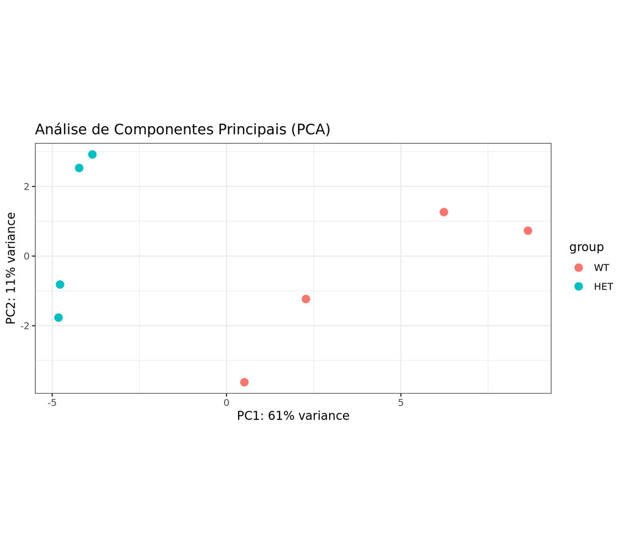

### 3.4 Volcano Plot

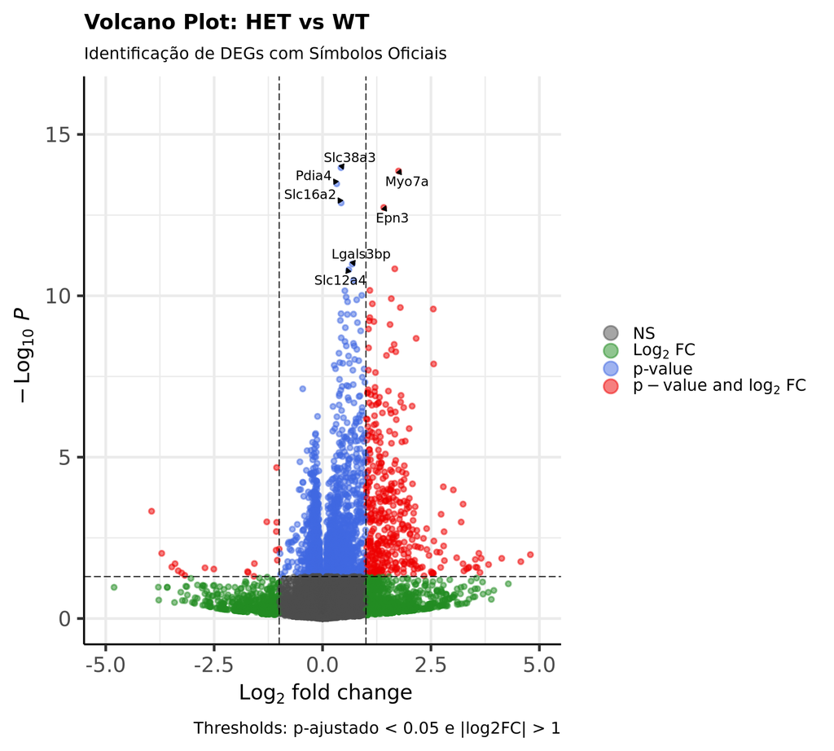

### 3.5 Heatmap dos Top Genes DE

O mapa de calor exibe o padrão de expressão dos top 50 genes mais significativamente alterados, evidenciando o agrupamento das amostras.  
Quanto mais próximo ao vermelho, maior a super-expressão (gene upregulated), enquanto que mais próximos azul maior maior sub-expressos (gene downregulated).

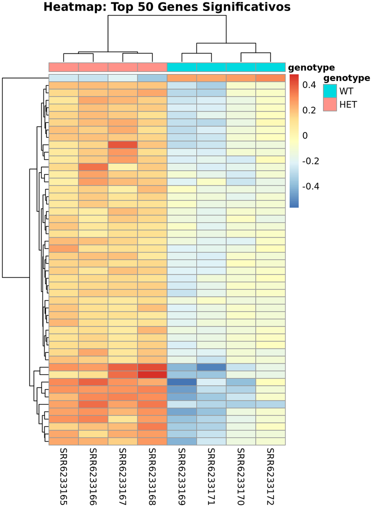

### 3.6 MA Plot

O MA Plot projeta a mudança em log2 (*Log2 Fold Change*) no eixo Y contra a média das contagens normalizadas no eixo X. Ele permite visualizar a distribuição dos genes diferencialmente expressos em diferentes níveis de abundância basal.  
O gráfico gerado demonstra uma marcante assinatura de regulação positiva (*up-regulation*), evidenciada pela concentração massiva de pontos azuis estatisticamente significativos ($p\text{-ajustado} < 0.05$) localizados acima da linha horizontal de baseline zero. Os pequenos triângulos dispostos nas extremidades superior e inferior indicam alvos com magnitudes extremas de variação que extrapolaram os limites de escala adotados.  
A detecção de genes diferencialmente expressos estende-se de forma homogênea desde faixas moderadas de contagens médias ($10^1$) até genes altamente abundantes no transcriptoma do hipocampo ($10^4$). Isso confirma a robustez do sequenciamento e valida a eficácia do algoritmo em isolar variações biológicas reais do ruído de amostragem inerente a genes de baixa expressão.

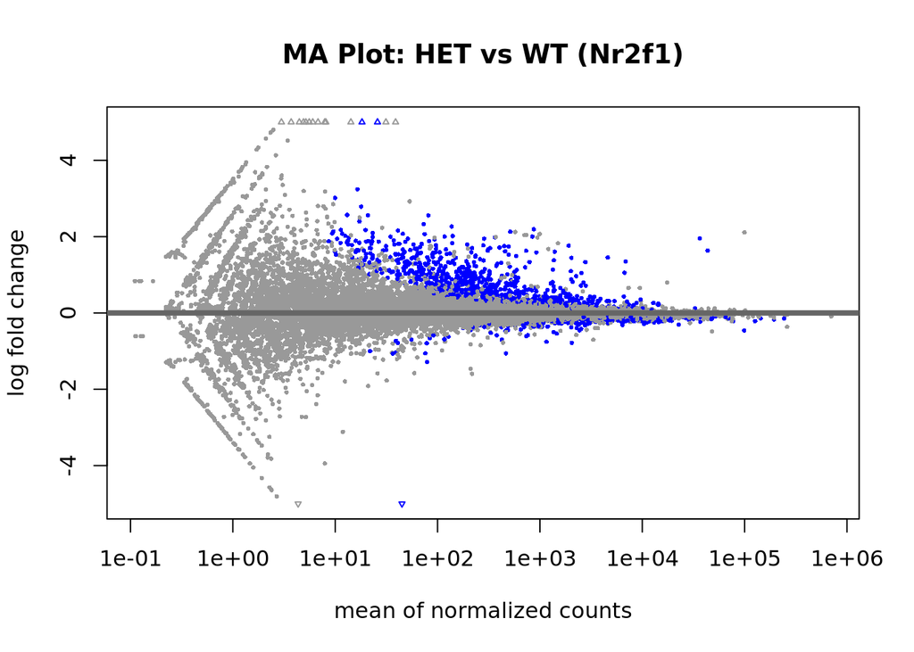

### 3.7 Enriquecimento Funcional (GO e KEGG)

### 3.7.1 Top Vias de Ontologia Gênica (GO)

As principais funções enriquecidas para Processos Biológicos (BP) estão listadas abaixo:

#### **Tabela de Termos GO Top 10**

| ID | Description | GeneRatio | p.adjust |
| --- | --- | --- | --- |
| GO:0003341 | cilium movement | 70/843 | 0 |
| GO:0044782 | cilium organization | 75/843 | 0 |
| GO:0060294 | cilium movement involved in cell motility | 54/843 | 0 |
| GO:0001539 | cilium or flagellum-dependent cell motility | 54/843 | 0 |
| GO:0060285 | cilium-dependent cell motility | 54/843 | 0 |
| GO:0097722 | sperm motility | 51/843 | 0 |
| GO:0035082 | axoneme assembly | 36/843 | 0 |
| GO:0030317 | flagellated sperm motility | 50/843 | 0 |
| GO:0001578 | microtubule bundle formation | 40/843 | 0 |
| GO:0060271 | cilium assembly | 65/843 | 0 |

Como o Nr2f1 controla a proliferação celular, a migração de neurônios e a diferenciação de células da glia, as vias que aparecem no topo da lista são pertencentes ao grupo de processos celulares que coordenam a estrutura e a função dos cílios e flagelos, pois o controle dos microtúbulos e dos cílios é crucial durante o processo de diferenciação do sistema nervoso.

#### **Barplot de Enriquecimento (GO)**

Este gráfico exibe o nível de significância das principais categorias biológicas, ordenadas pelo p-valor ajustado.

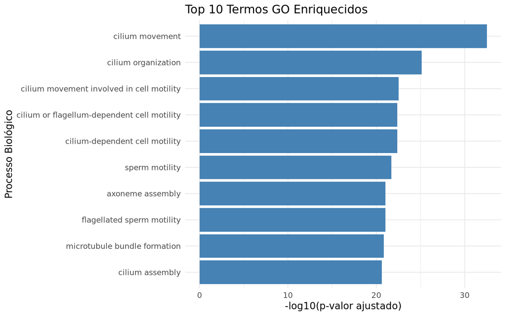

Com essas vias super-expressas, os cílios e o esqueleto dos neurônios sofrem uma hiperestimulação ou desorganização estrutural, prejudicando a migração dos neurônios e a fiação das sinapses, explicando os problemas severos de cognição, memória e os defeitos visuais que caracterizam a síndrome de BBSOAS.

### 3.7.2 Top Vias Metabólicas (KEGG)

As principais cascatas biológicas afetadas de acordo com o KEGG consistem em:

| ID | Description | GeneRatio | p.adjust |
| --- | --- | --- | --- |
| mmu04820 | Cytoskeleton in muscle cells | 23/392 | 0.0019821 |
| mmu04512 | ECM-receptor interaction | 13/392 | 0.0019821 |
| mmu04518 | Integrin signaling | 17/392 | 0.0026972 |
| mmu04933 | AGE-RAGE signaling pathway in diabetic complications | 13/392 | 0.0039305 |
| mmu04814 | Motor proteins | 19/392 | 0.0042853 |
| mmu04390 | Hippo signaling pathway | 16/392 | 0.0071036 |
| mmu04142 | Lysosome biogenesis | 21/392 | 0.0108276 |
| mmu05205 | Proteoglycans in cancer | 18/392 | 0.0119023 |

Percebemos um enriquecimento de vias que se evidenciam pelo impacto na arquitetura física da célula (citoesqueleto), na comunicação com o ambiente externo (matriz extracelular) e nas vias de sobrevivência e sinalização celular.

#### **Dotplot de Vias (KEGG)**

O gráfico (*Dotplot*) ilustra simultaneamente a proporção de genes alterados na via (tamanho da bolinha) e a significância estatística do enriquecimento (gradiente de cor).

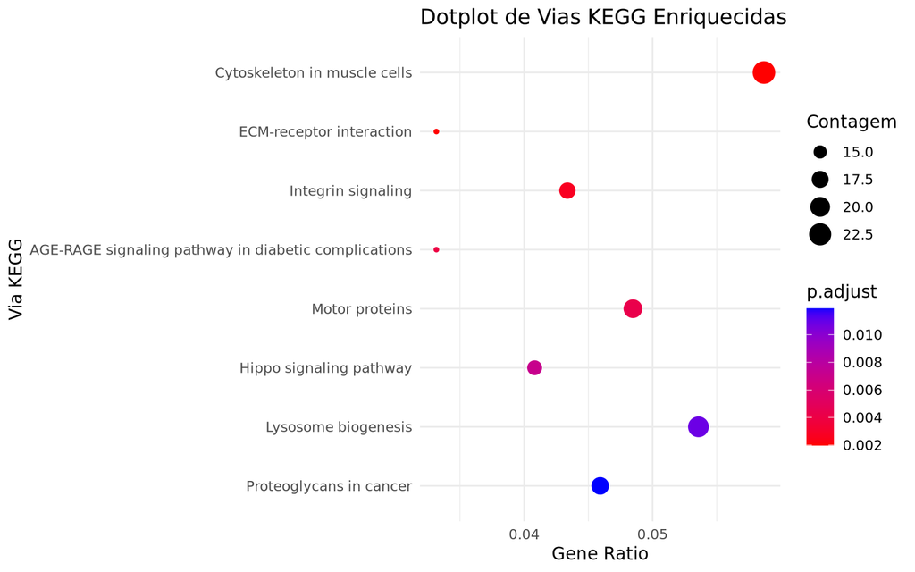

A ativação coordenada dessas vias (especialmente ECM-receptor, Integrinas, Proteoglicanos e Proteínas Motoras) indica que o hipocampo HET está sofrendo uma remodelação massiva na sua estrutura física e na sua matriz extracelular.  
Como o gene Nr2f1 regula o desenvolvimento e a migração neuronal, a desregulação dessas cascatas sugere que as células mutantes encontram um ambiente físico alterado e apresentam motores moleculares desajustados. Isso impede que os neurônios migrem corretamente e estabeleçam conexões (sinapses) funcionais, então, podemos correlacionar com o déficit de aprendizado e memória característicos da Síndrome de BBSOAS.

### 3.7.3 Análise de Enriquecimento de Conjunto de Genes por NES (GSEA)

Diferente do enriquecimento tradicional, o GSEA utiliza o ranqueamento completo dos genes para identificar caminhos biológicos coordenadamente ativados (Up-regulated) ou reprimidos (Down-regulated).

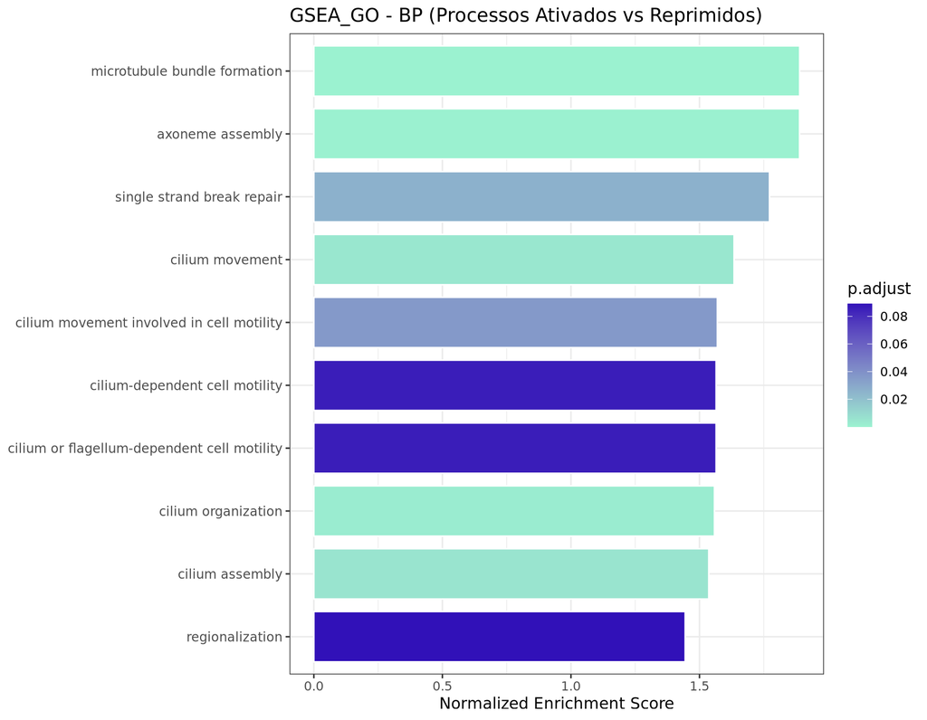

## 4. Discussão

### 4.1 Tabela de Anotação e Impacto dos Genes Alvo

A tabela abaixo unifica o ID estável, a direção do impacto (Condition) calculada pelo DESeq2, o símbolo oficial do gene e a descrição funcional completa de sua proteína:

| Ensembl ID | Gene Name | Condition | Brief Description |
| --- | --- | --- | --- |
| ENSMUSG00000048416 | Mlf1 | Upregulated | myeloid leukemia factor 1 |
| ENSMUSG00000069171 | Nr2f1 | Downregulated | nuclear receptor subfamily 2, group F, member 1 |
| ENSMUSG00000032373 | Car12 | Upregulated | carbonic anhydrase 12 |
| ENSMUSG00000010064 | Slc38a3 | Upregulated | solute carrier family 38, member 3 |
| ENSMUSG00000030761 | Myo7a | Upregulated | myosin VIIA |
| ENSMUSG00000025823 | Pdia4 | Upregulated | protein disulfide isomerase associated 4 |
| ENSMUSG00000033965 | Slc16a2 | Upregulated | solute carrier family 16 (monocarboxylic acid transporters), member 2 |
| ENSMUSG00000010080 | Epn3 | Upregulated | epsin 3 |
| ENSMUSG00000033880 | Lgals3bp | Upregulated | lectin, galactoside-binding, soluble, 3 binding protein |
| ENSMUSG00000017765 | Slc12a4 | Upregulated | solute carrier family 12, member 4 |
| ENSMUSG00000021806 | Nid2 | Upregulated | nidogen 2 |
| ENSMUSG00000017754 | Pltp | Upregulated | phospholipid transfer protein |
| ENSMUSG00000027750 | Postn | Upregulated | periostin, osteoblast specific factor |
| ENSMUSG00000029287 | Tgfbr3 | Upregulated | transforming growth factor, beta receptor III |
| ENSMUSG00000031303 | Map3k15 | Upregulated | mitogen-activated protein kinase kinase kinase 15 |

## 5. Referências

1. **Artigo do Dataset:** Chen CA, Wang W, Pedersen SE, Raman A, Seymour ML, Ruiz FR, Xia A, van der Heijden ME, Wang L, Yin J, Lopez J, Rech ME, Lewis RA, Wu SM, Liu Z, Pereira FA, Pautler RG, Zoghbi HY, Schaaf CP. Nr2f1 heterozygous knockout mice recapitulate neurological phenotypes of Bosch-Boonstra-Schaaf optic atrophy syndrome and show impaired hippocampal synaptic plasticity. Hum Mol Genet. 2020 Mar 27;29(5):705-715. doi: 10.1093/hmg/ddz233. PMID: 31600777; PMCID: PMC7104670.
2. **Snakemake:** Mölder, F., et al. (2021). Sustainable data analysis with Snakemake. *F1000Research*.
3. **DESeq2:** Love, M.I., Huber, W., & Anders, S. (2014). Moderated estimation of fold change and dispersion for RNA-seq data with DESeq2. *Genome Biology*.
4. **Salmon:** Patro, R., et al. (2017). Salmon provides fast and bias-free quantification of transcript expression. *Nature Methods*.
5. **clusterProfiler:** Wu, T., et al. (2021). clusterProfiler 4.0: A universal enrichment tool for interpreting omics data. *The Innovation*.